# **Panorama da inflação**

Os principais índices de inflação do Brasil, apontam em abril de 2021 um avanço da inflação de em média **0.73%**. Com esse resultado, no ano a inflação acumula uma variação média positiva de **3.95%**, e em 12 meses uma variação média acumulada de **15.46%**.

[output not shown]

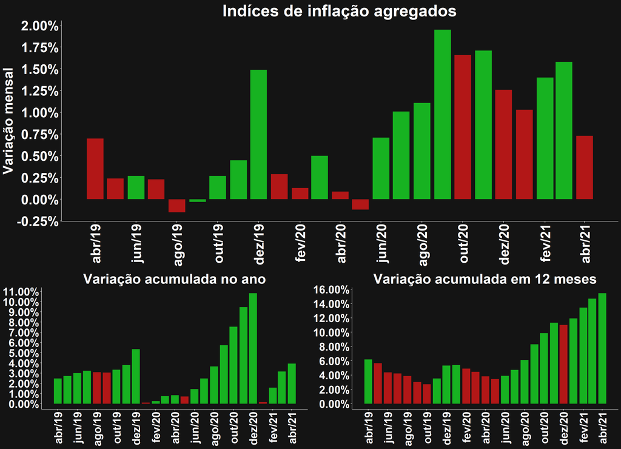

Índices selecionados para a média: IPCA, INPC e IGP-M.

# IPCA

O Indíce de Preços ao Consumidor Amplo (IPCA) variou 0.31% em abril, valor superior ao mesmo período do ano anterior quando apresentou uma taxa de -0.31%. Com esse resultado o indíce acumula no ano uma variação positiva de 2.37%, e em 12 meses uma variação positiva de 6.76%.

|  | 04/2020 | 03/2021 | 04/2021 |
| --- | --- | --- | --- |
| Variação mensal | -0.31% | 0.93% | 0.31% |
| Variação acumulada no ano | 0.22% | 2.05% | 2.37% |
| Variação acumulada em 12 meses | 2.4% | 6.1% | 6.76% |

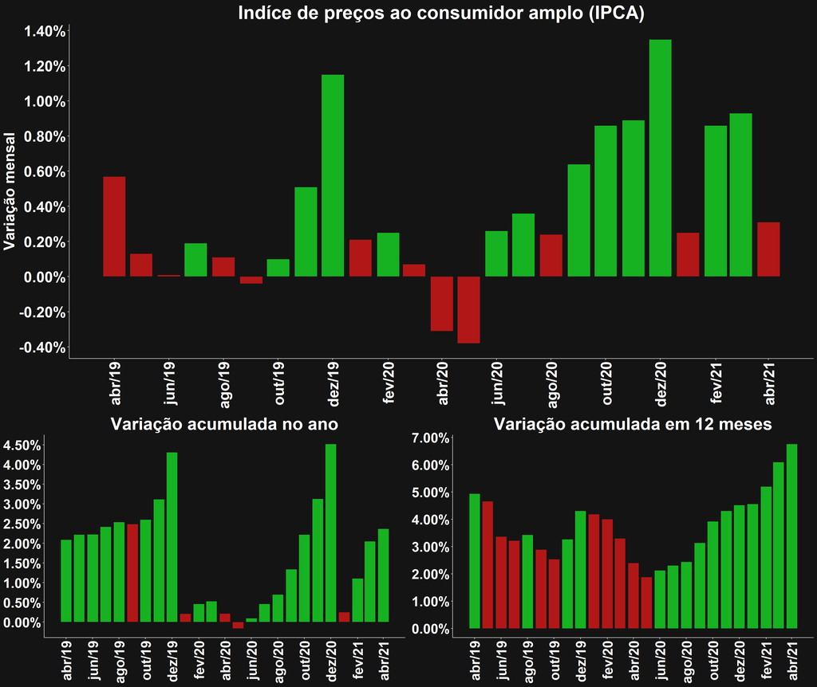

|  | Variação mensal | Variação acumulada no ano | Peso mensal |
| --- | --- | --- | --- |
| Alimentação e bebidas | 0.4% | 1.83% | 20.99% |
| Habitação | 0.22% | 0.35% | 15.41% |
| Artigos de residência | 0.57% | 2.81% | 3.81% |
| Vestuário | 0.47% | 1.07% | 4.27% |
| Transportes | -0.08% | 6.53% | 20.8% |
| Saúde e cuidados pessoais | 1.19% | 2.12% | 13% |
| Despesas pessoais | 0.01% | 0.61% | 10.23% |
| Educação | 0.04% | 2.12% | 5.95% |
| Comunicação | 0.08% | -0.1% | 5.53% |

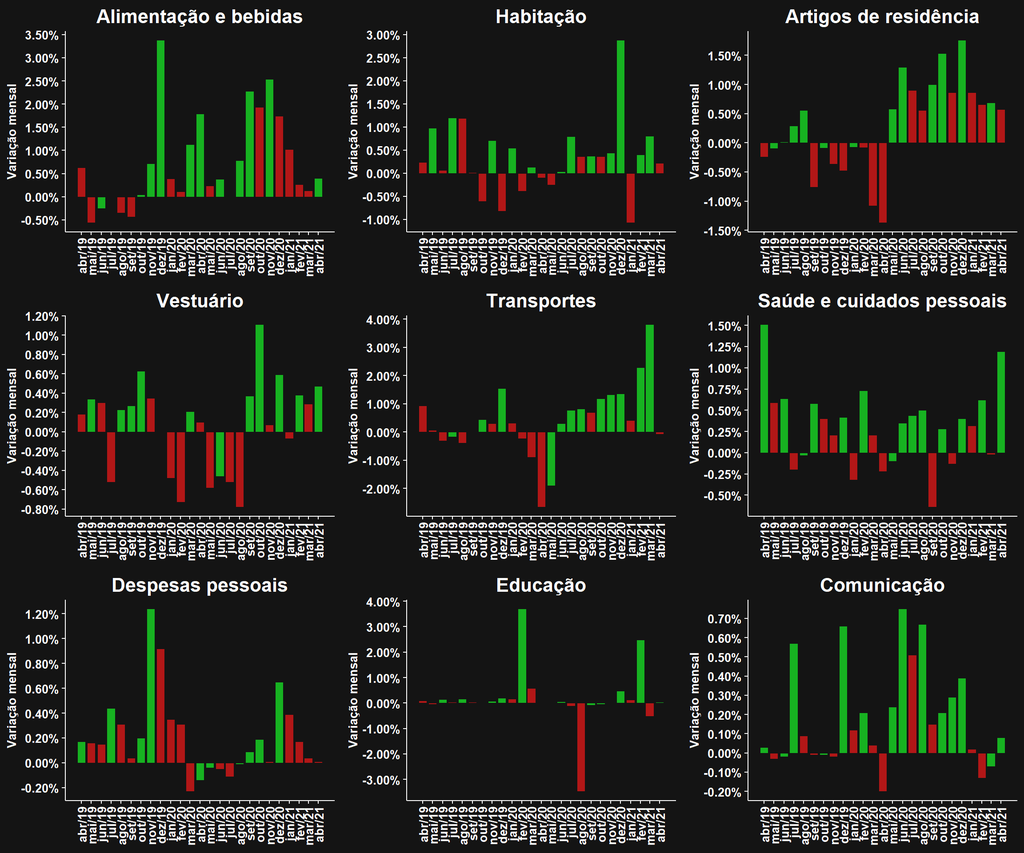

A nível de sub-itens os que mais influenciaram positivamente no resultado em relação ao seu peso foram Perfume (3.67%%) e Automóvel novo (1.01%%), e negativamente Etanol (-4.93%%) e Produto para pele (-6.77%%).

|  | Variação mensal | Variação acumulada no ano | Peso mensal |
| --- | --- | --- | --- |
| Passagem aérea | 6.41% | -19.01% | 0.41% |
| Perfume | 3.67% | 5.02% | 1.03% |
| Automóvel novo | 1.01% | 3.6% | 2.96% |
| Plano de saúde | 0.67% | 2.7% | 3.95% |

|  | Variação mensal | Variação acumulada no ano | Peso mensal |
| --- | --- | --- | --- |
| Gasolina | -0.44% | 21.22% | 5.86% |
| Seguro voluntário de veículo | -3.03% | 0.83% | 0.75% |
| Etanol | -4.93% | 17.67% | 0.79% |
| Produto para pele | -6.77% | -5.8% | 0.38% |

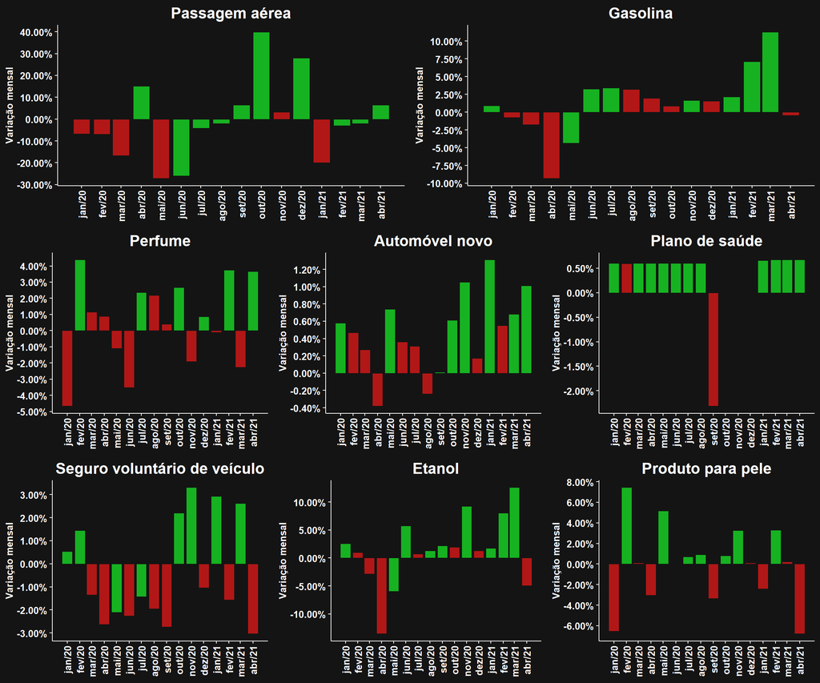

# INPC

O Indíce Nacional de Preços ao Consumidor (INPC) variou 0.38% em abril, valor superior ao mesmo período do ano anterior quando apresentou uma taxa de -0.23%. Com esse resultado o indíce acumula no ano uma variação positiva de 2.35%, e em 12 meses uma variação positiva de 7.59%.

|  | 04/2020 | 03/2021 | 04/2021 |
| --- | --- | --- | --- |
| Variação mensal | -0.23% | 0.86% | 0.38% |
| Variação acumulada no ano | 0.31% | 1.96% | 2.35% |
| Variação acumulada em 12 meses | 2.46% | 6.94% | 7.59% |

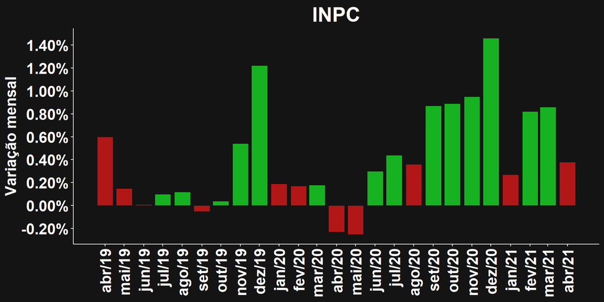

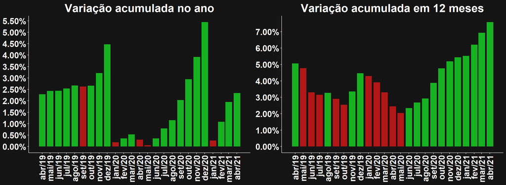

# IGP-M

O Indíce Geral de Preços de Mercado (IGP-M) variou 1.51% em abril, valor superior ao mesmo período do ano anterior quando apresentou uma taxa de 0.8%. Com esse resultado o indíce acumula no ano uma variação positiva de 7.13%, e em 12 meses uma variação positiva de 32.02%.

|  | 04/2020 | 03/2021 | 04/2021 |
| --- | --- | --- | --- |
| Variação mensal | 0.8% | 2.94% | 1.51% |
| Variação acumulada no ano | 2.01% | 5.54% | 7.13% |
| Variação acumulada em 12 meses | 6.68% | 31.1% | 32.02% |

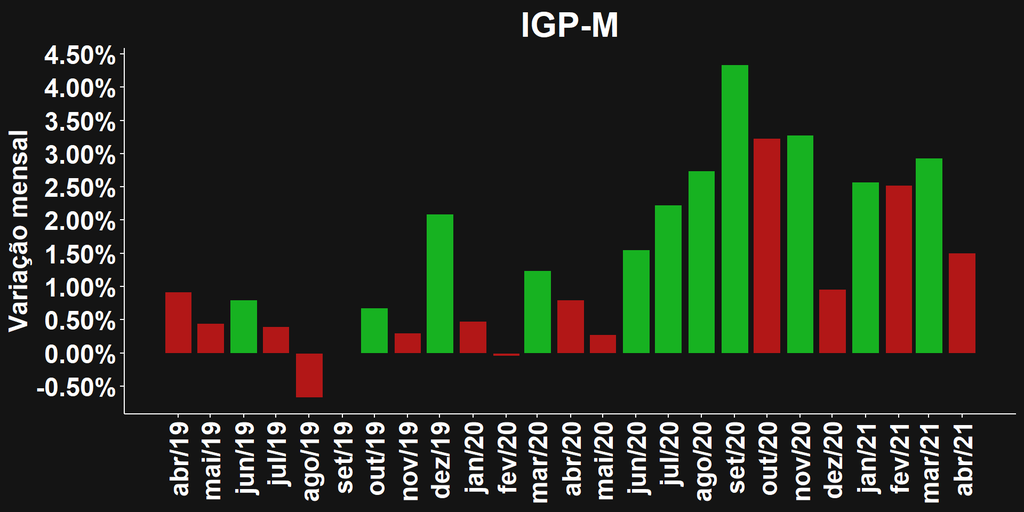

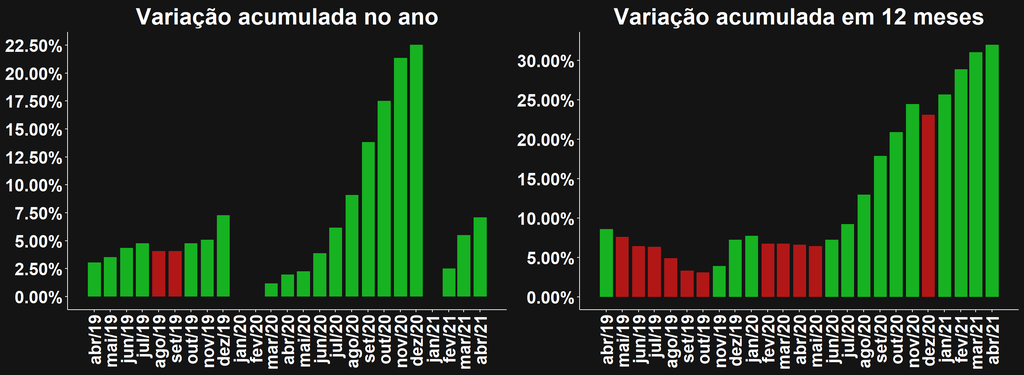

# IGP-DI

O Indíce Geral de Preços - Disponibilidade Interna (IGP-DI) variou 2.22% em abril, valor superior ao mesmo período do ano anterior quando apresentou uma taxa de 0.05%. Com esse resultado o indíce acumula no ano uma variação positiva de 7.26%, e em 12 meses uma variação positiva de 33.46%.

|  | 04/2020 | 03/2021 | 04/2021 |
| --- | --- | --- | --- |
| Variação mensal | 0.05% | 2.17% | 2.22% |
| Variação acumulada no ano | 1.71% | 4.93% | 7.26% |
| Variação acumulada em 12 meses | 6.1% | 30.63% | 33.46% |

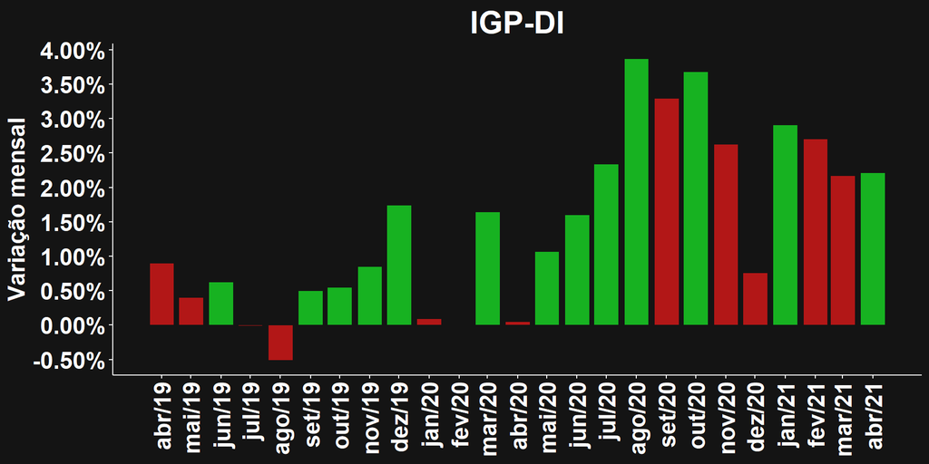

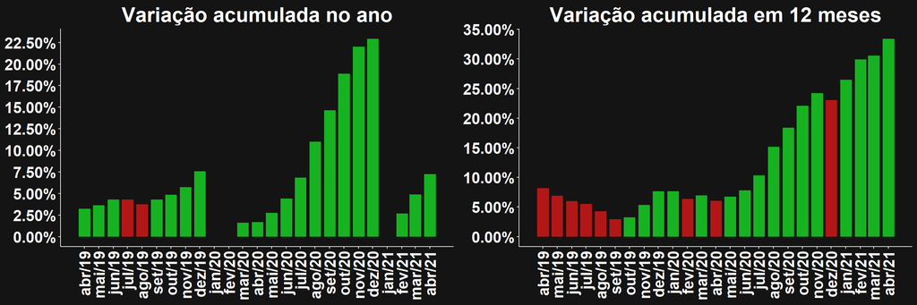

[output not shown]

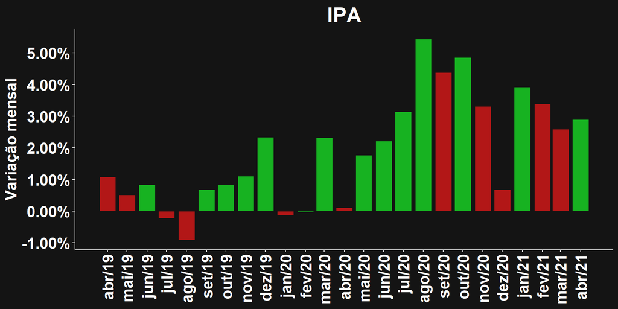

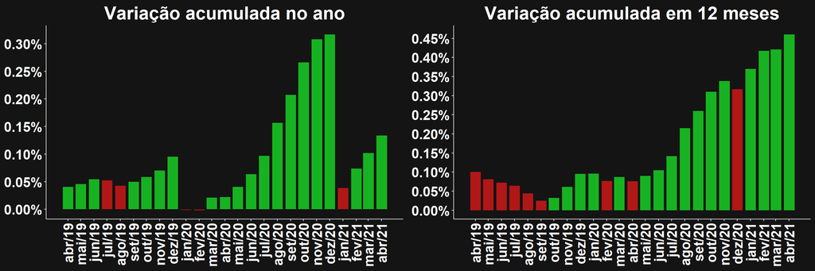

O Indíce de Preços ao Consumidor (IPC), integrante do IGP-DI com peso de 30%, apresentou variação de 0.23% em abril, valor superior ao mesmo período do ano anterior quando apresentou uma taxa de -0.18%. Com esse resultado o indíce acumula no ano uma variação positiva de 1.77%, e em 12 meses uma variação positiva de 6.54%.

|  | 04/2020 | 03/2021 | 04/2021 |
| --- | --- | --- | --- |
| Variação mensal | -0.18% | 1% | 0.23% |
| Variação acumulada no ano | 0.15% | 1.54% | 1.77% |
| Variação acumulada em 12 meses | 2.6% | 6.1% | 6.54% |

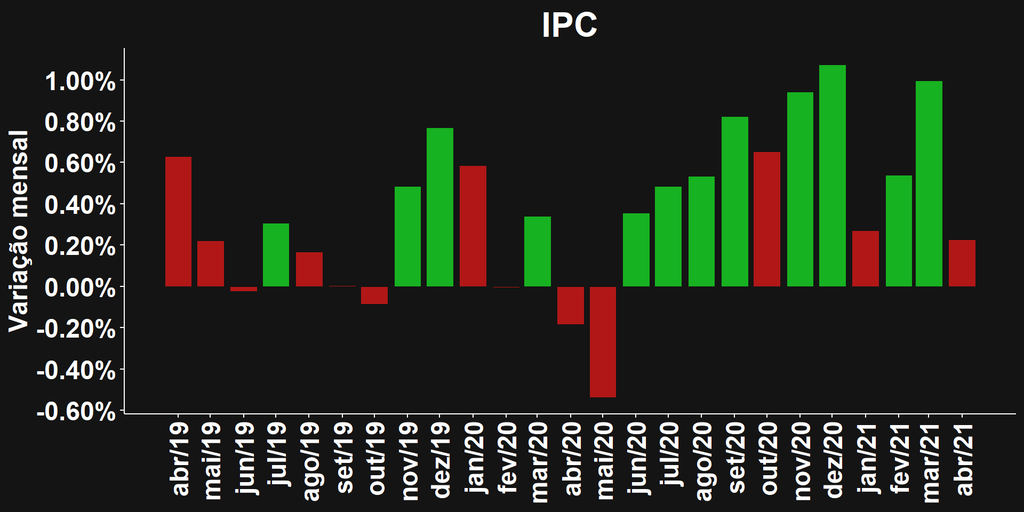

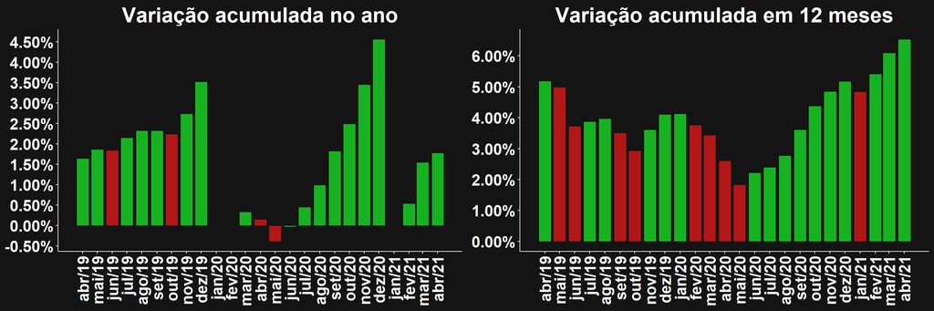

O Indíce Nacional de Custos de Construção (INCC), integrante do IGP-DI com peso de 10%, apresentou variação de 0.9% em abril, valor superior ao mesmo período do ano anterior quando apresentou uma taxa de 0.22%. Com esse resultado o indíce acumula no ano uma variação positiva de 4.15%, e em 12 meses uma variação positiva de 12.99%.

|  | 04/2020 | 03/2021 | 04/2021 |
| --- | --- | --- | --- |
| Variação mensal | 0.22% | 1.3% | 0.9% |
| Variação acumulada no ano | 0.81% | 3.22% | 4.15% |
| Variação acumulada em 12 meses | 4.06% | 12.23% | 12.99% |

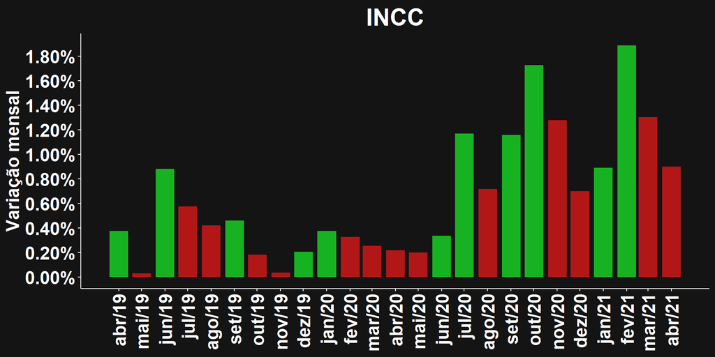

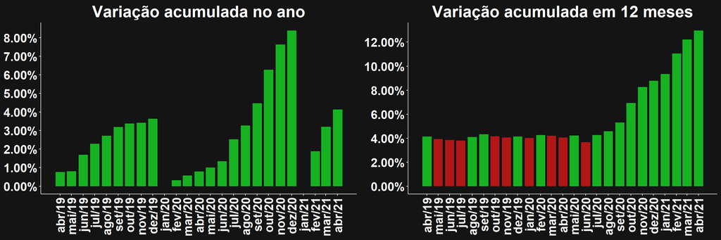

# Estatísticas

As estatísticas descritivas a seguir são feitas com base nos últimos 48 meses, e tem como objetivo possibilitar a avaliação do resultado observado em comparação aos períodos anteriores.

|  | Minimo | 1 Quartil | Mediana | Media | 3 Quartil | Maximo | Desvio Padrão |
| --- | --- | --- | --- | --- | --- | --- | --- |
| IPCA | -0.38% | 0.14% | 0.28% | 0.34% | 0.46% | 1.35% | 0.37% |
| INPC | -0.3% | 0.12% | 0.26% | 0.34% | 0.47% | 1.46% | 0.4% |
| IGP-M | -1.08% | 0.26% | 0.73% | 0.94% | 1.51% | 4.34% | 1.18% |
| IGP-DI | -1.14% | 0.14% | 0.71% | 0.96% | 1.64% | 3.87% | 1.16% |
| IPA | -1.7% | 0.14% | 0.98% | 1.22% | 2.33% | 5.44% | 1.62% |
| IPC | -0.54% | 0.17% | 0.34% | 0.35% | 0.55% | 1.19% | 0.35% |
| INCC | 0.03% | 0.22% | 0.33% | 0.51% | 0.71% | 1.89% | 0.44% |

Levando em consideração o desvio padrão de cada indíce, proporcionalmente os que mais se afastaram da média foram o IGP-DI, o IPA e o INCC.

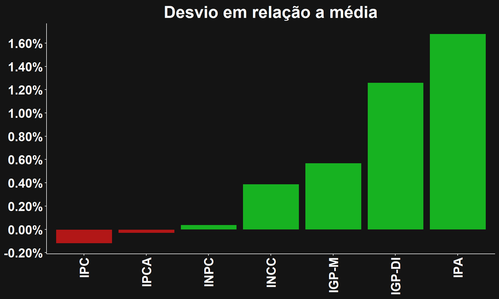

**João Victor Gomes**  
**jvg.santana@gmail.com**  
**[linkedin.com/in/jvictorgomes](https://www.linkedin.com/in/jvictorgomes/)**